# LAB7

2/28/2019

## Outline

**Web APIs:**

Web APIs (application programming interface): website offers a set of structured http requests that return JSON or XML files.

- R packages: `rtweet` (twitter), `Rfacebook` (facebook), `RedditExtractoR` (reddit), `imdbapi` (IMDB), `omdbapi`(The Open Movie Database).
- API request from R. `rjson` (map JSON file to datafram),`rvest` (web scrapping).

**Twitter API**

- Retweet networks
- Friendship networks
- API authorization
- API request
- Creating networks based on datasets (Retweet networks)
- **Multiple requests based on results (Friendship networks)**

## Preparation

```r
#install.packages("rtweet")
library("rtweet")
library(dplyr)
library(igraph)
library(purrr)
library("stringr")
```

## Retweet networks

```r
rt_duke <- search_tweets(
  "#duke", n = 1000
)
```

```
## Searching for tweets...
```

```
## Finished collecting tweets!
```

```r
nrow(rt_duke)
```

```
## [1] 977
```

```r
names(rt_duke)
```

```
##  [1] "user_id"                 "status_id"
##  [3] "created_at"              "screen_name"
##  [5] "text"                    "source"
##  [7] "display_text_width"      "reply_to_status_id"
##  [9] "reply_to_user_id"        "reply_to_screen_name"
## [11] "is_quote"                "is_retweet"
## [13] "favorite_count"          "retweet_count"
## [15] "hashtags"                "symbols"
## [17] "urls_url"                "urls_t.co"
## [19] "urls_expanded_url"       "media_url"
## [21] "media_t.co"              "media_expanded_url"
## [23] "media_type"              "ext_media_url"
## [25] "ext_media_t.co"          "ext_media_expanded_url"
## [27] "ext_media_type"          "mentions_user_id"
## [29] "mentions_screen_name"    "lang"
```

[output cut: 29 more lines]

```r
netdf=rt_duke%>%dplyr::select(.,screen_name,retweet_screen_name,is_retweet)
netdfr=netdf%>%filter(is_retweet)%>%select(-is_retweet)
netdfp=netdf%>%filter(!is_retweet)%>%pull(screen_name)
igra_duke=graph_from_data_frame(netdfr)#+netdfp
E(igra_duke)$weight=rep(1,ecount(igra_duke))
igra_duke_s <- igraph::simplify( igra_duke, remove.multiple = T, remove.loops = F,
                 edge.attr.comb=c(weight="sum"))
igra_duke_s
```

```
## IGRAPH 92a2599 DNW- 584 534 --
## + attr: name (v/c), weight (e/n)
## + edges from 92a2599 (vertex names):
##  [1] AlejandroV_52  ->SportsSidelined gobigorgohome71->rhj_24324
##  [3] deswhitley5    ->SportsSidelined Pee_Jay_081    ->quagg23
##  [5] SpurlockBlake  ->rhj_24324       TrueMartian14  ->rhj_24324
##  [7] TrueMartian14  ->bluedevilmike   knownazzkinge  ->SportsSidelined
##  [9] Swaggyweb_     ->SportsSidelined KingGeorgee3   ->SportsSidelined
## [11] og97__         ->SportsSidelined CozyAtoZ       ->ForCollecting
## [13] zachchc        ->SportsSidelined org_gb_poe     ->SportsSidelined
## [15] Reikkk_        ->SportsSidelined CordellCockett3->SportsSidelined
## + ... omitted several edges
```

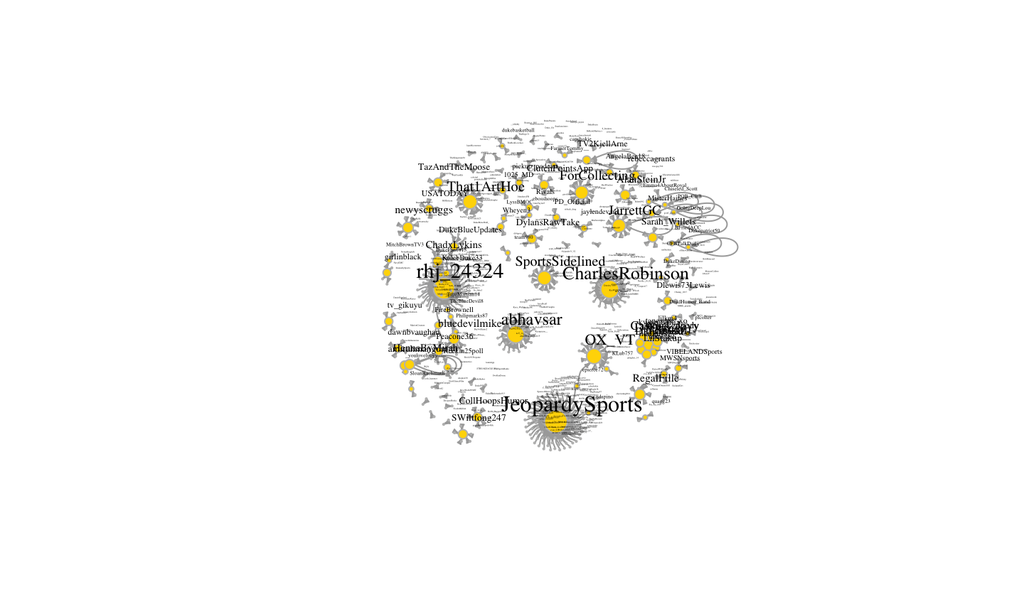

```r
plot(igra_duke_s,vertex.color="gold", vertex.size=log(degree(igra_duke_s))*3+1,
     vertex.frame.color="gray", vertex.label.color="black",
     vertex.label.cex=log(degree(igra_duke_s))*0.2+0.1, vertex.label.dist=2, edge.curved=0.5,edge.arrow.size=.2)
```

## Friendship networks

## Friendship networks

Friendship network of NYC political science

directed: following

`get_friends()`: Get user IDs of accounts followed by target user(s).

```r
##maximum ids: 100
user.seed="drewconway"
user.following=get_friends(user.seed,n=500,retryonratelimit = TRUE)
nrow(user.following)
```

```
## [1] 297
```

```r
user.following%>%head(5)
```

```
## # A tibble: 5 x 2
##   user       user_id
##   <chr>      <chr>
## 1 drewconway 5850692
## 2 drewconway 132496568
## 3 drewconway 15276573
## 4 drewconway 13524182
## 5 drewconway 16039252
```

## filter on the following user list

```r
info.following=lookup_users(user.following$user_id)
info.following
```

```
## # A tibble: 297 x 88
##    user_id status_id created_at          screen_name text  source
##    <chr>   <chr>     <dttm>              <chr>       <chr> <chr>
##  1 5850692 11011658… 2019-02-28 17:02:54 Aaroth      "@ge… Twitt…
##  2 132496… 11011803… 2019-02-28 18:00:32 NewYorkSta… Toda… Twitt…
##  3 152765… 11011749… 2019-02-28 17:39:02 drewharwell "A @… Tweet…
##  4 135241… 11011821… 2019-02-28 18:07:28 daveweigel  I wa… Twitt…
##  5 160392… 11011522… 2019-02-28 16:08:47 pklinkne    @jon… Twitt…
##  6 235070… 11004319… 2019-02-26 16:26:32 stasavage   @jam… Twitt…
##  7 881321… 11011390… 2019-02-28 15:16:19 BackAftaTh… @jbr… Twitt…
##  8 108347… 11011719… 2019-02-28 17:27:07 random_wal… Exci… Twitt…
##  9 269349… 11011807… 2019-02-28 18:01:59 TheFFBalle… MERC… Twitt…
## 10 902956… 11004417… 2019-02-26 17:05:40 HutchEleme… A gl… Twitt…
## # … with 287 more rows, and 82 more variables: display_text_width <int>,
## #   reply_to_status_id <chr>, reply_to_user_id <chr>,
## #   reply_to_screen_name <chr>, is_quote <lgl>, is_retweet <lgl>,
## #   favorite_count <int>, retweet_count <int>, hashtags <list>,
## #   symbols <list>, urls_url <list>, urls_t.co <list>,
## #   urls_expanded_url <list>, media_url <list>, media_t.co <list>,
## #   media_expanded_url <list>, media_type <list>, ext_media_url <list>,
## #   ext_media_t.co <list>, ext_media_expanded_url <list>,
## #   ext_media_type <chr>, mentions_user_id <list>,
## #   mentions_screen_name <list>, lang <chr>, quoted_status_id <chr>,
## #   quoted_text <chr>, quoted_created_at <dttm>, quoted_source <chr>,
## #   quoted_favorite_count <int>, quoted_retweet_count <int>,
## #   quoted_user_id <chr>, quoted_screen_name <chr>, quoted_name <chr>,
## #   quoted_followers_count <int>, quoted_friends_count <int>,
## #   quoted_statuses_count <int>, quoted_location <chr>,
## #   quoted_description <chr>, quoted_verified <lgl>,
## #   retweet_status_id <chr>, retweet_text <chr>,
## #   retweet_created_at <dttm>, retweet_source <chr>,
## #   retweet_favorite_count <int>, retweet_retweet_count <int>,
## #   retweet_user_id <chr>, retweet_screen_name <chr>, retweet_name <chr>,
## #   retweet_followers_count <int>, retweet_friends_count <int>,
## #   retweet_statuses_count <int>, retweet_location <chr>,
## #   retweet_description <chr>, retweet_verified <lgl>, place_url <chr>,
## #   place_name <chr>, place_full_name <chr>, place_type <chr>,
## #   country <chr>, country_code <chr>, geo_coords <list>,
## #   coords_coords <list>, bbox_coords <list>, status_url <chr>,
## #   name <chr>, location <chr>, description <chr>, url <chr>,
## #   protected <lgl>, followers_count <int>, friends_count <int>,
## #   listed_count <int>, statuses_count <int>, favourites_count <int>,
## #   account_created_at <dttm>, verified <lgl>, profile_url <chr>,
## #   profile_expanded_url <chr>, account_lang <chr>,
## #   profile_banner_url <chr>, profile_background_url <chr>,
## #   profile_image_url <chr>
```

```r
names(info.following)
```

```
##  [1] "user_id"                 "status_id"
##  [3] "created_at"              "screen_name"
##  [5] "text"                    "source"
##  [7] "display_text_width"      "reply_to_status_id"
##  [9] "reply_to_user_id"        "reply_to_screen_name"
## [11] "is_quote"                "is_retweet"
## [13] "favorite_count"          "retweet_count"
## [15] "hashtags"                "symbols"
## [17] "urls_url"                "urls_t.co"
## [19] "urls_expanded_url"       "media_url"
## [21] "media_t.co"              "media_expanded_url"
## [23] "media_type"              "ext_media_url"
## [25] "ext_media_t.co"          "ext_media_expanded_url"
## [27] "ext_media_type"          "mentions_user_id"
## [29] "mentions_screen_name"    "lang"
```

[output cut: 29 more lines]

```r
##choose the filtering criterion: description, verified (blue check mark), location
info.following%>%select(geo_coords,country,country_code,location)%>%lat_lng()
```

```
## # A tibble: 297 x 8
##    geo_coords country country_code location   lat   lng coords_coords
##    <list>     <chr>   <chr>        <chr>    <dbl> <dbl>         <dbl>
##  1 <dbl [2]>  <NA>    <NA>         Philade…    NA    NA            NA
##  2 <dbl [2]>  <NA>    <NA>         New York    NA    NA            NA
##  3 <dbl [2]>  <NA>    <NA>         D.C.        NA    NA            NA
##  4 <dbl [2]>  <NA>    <NA>         Washing…    NA    NA            NA
##  5 <dbl [2]>  <NA>    <NA>         ""          NA    NA            NA
##  6 <dbl [2]>  <NA>    <NA>         New Yor…    NA    NA            NA
##  7 <dbl [2]>  <NA>    <NA>         ""          NA    NA            NA
##  8 <dbl [2]>  <NA>    <NA>         Princet…    NA    NA            NA
##  9 <dbl [2]>  <NA>    <NA>         Phoenix…    NA    NA            NA
## 10 <dbl [2]>  <NA>    <NA>         Pelham,…    NA    NA            NA
## # … with 287 more rows, and 1 more variable: bbox_coords <dbl>
```

```r
## filter based on description
candidates=info.following%>%filter(description%>%
                          str_detect("nyu|new york university"),
                        description%>%
                          str_detect("poli(tics|tical|sci|cy)"))%>%
  select(user_id,screen_name,name,friends_count,description)
candidates%>%head(5)
```

```
## # A tibble: 1 x 5
##   user_id  screen_name name     friends_count description
##   <chr>    <chr>       <chr>            <int> <chr>
## 1 8448612… zeitzoff    Thomas …          2602 Associate professor @AU_SPA.…
```

## request rate limit

`rate_limit`

https://developer.twitter.com/en/docs/developer-utilities/rate-limit-status/api-reference/get-application-rate_limit_status

```r
rate_limit()%>%head()
```

```
## # A tibble: 6 x 7
##   query limit remaining reset reset_at            timestamp           app
##   <chr> <int>     <int> <tim> <dttm>              <dttm>              <chr>
## 1 list…    15        15 15.0… 2019-02-28 13:29:25 2019-02-28 13:14:24 Test…
## 2 list…    75        75 15.0… 2019-02-28 13:29:25 2019-02-28 13:14:24 Test…
## 3 list…    15        15 15.0… 2019-02-28 13:29:25 2019-02-28 13:14:24 Test…
## 4 list…   900       900 15.0… 2019-02-28 13:29:25 2019-02-28 13:14:24 Test…
## 5 list…    15        15 15.0… 2019-02-28 13:29:25 2019-02-28 13:14:24 Test…
## 6 list…    75        75 15.0… 2019-02-28 13:29:25 2019-02-28 13:14:24 Test…
```

```r
rate_limit("get_friends")
```

```
## # A tibble: 1 x 7
##   query limit remaining reset reset_at            timestamp           app
##   <chr> <int>     <int> <tim> <dttm>              <dttm>              <chr>
## 1 frie…    15        14 14.9… 2019-02-28 13:29:23 2019-02-28 13:14:24 Test…
```

```r
get_friends(c("drewconway","BarackObama"))
```

```
## 1 friend networks collected!
```

```
## 2 friend networks collected!
```

```
## # A tibble: 5,297 x 2
##    user       user_id
##    <chr>      <chr>
##  1 drewconway 5850692
##  2 drewconway 132496568
##  3 drewconway 15276573
##  4 drewconway 13524182
##  5 drewconway 16039252
##  6 drewconway 2350709449
##  7 drewconway 881321968301223937
##  8 drewconway 10834752
##  9 drewconway 2693496433
## 10 drewconway 902956529590120451
## # … with 5,287 more rows
```

```r
rate_limit("get_friends") # 15 every 15 min
```

```
## # A tibble: 1 x 7
##   query limit remaining reset reset_at            timestamp           app
##   <chr> <int>     <int> <tim> <dttm>              <dttm>              <chr>
## 1 frie…    15        12 14.9… 2019-02-28 13:29:23 2019-02-28 13:14:25 Test…
```

```r
rate_limit("lookup_users") # 900 every 15 min
```

```
## # A tibble: 1 x 7
##   query limit remaining reset reset_at            timestamp           app
##   <chr> <int>     <int> <tim> <dttm>              <dttm>              <chr>
## 1 user…   900       897 14.9… 2019-02-28 13:29:23 2019-02-28 13:14:25 Test…
```

```r
limit.fri=rate_limit("get_friends")
  if (limit.fri$remaining==0){
    Sys.sleep(60*as.numeric(limit.fri$reset))}
```

## Friendship network

```r
# seed user
user.seed= 20916144 #"cdsamii"
user.following=get_friends(user.seed,n=15,retryonratelimit = TRUE)
userid=c(user.seed,user.following$user_id)
info.following=lookup_users(userid)
user.df=info.following%>%filter(description%>%
                          str_detect(regex("nyu|new york university",ignore_case = T)),
                        description%>%
                          str_detect(regex("poli(tics|tical|sci|cy)",ignore_case = T))
                        )%>%
  select(user_id,screen_name,name,friends_count,description)
acc.id=user.df$user_id # qualified id
nyc.id=user.seed # already scrapped the friends
can.id=acc.id[!acc.id%in%nyc.id] # to be scrapped
rej.id=userid[!info.following$user_id%in%acc.id] # non-qualified
edge.list=user.following%>%filter(user_id%in%acc.id) # netowork
info.id=userid # already request user info
while((length(nyc.id)<100)){
  # pick the first user in the acc.id
user.following=get_friends(can.id,n=1000,retryonratelimit = TRUE)
userid=user.following$user_id
useridx=userid[!userid%in%info.id] # new userid
info.following=lookup_users(useridx)
user.dfx=info.following%>%filter(description%>%
                          str_detect(regex("nyu|new york university",ignore_case = T)),
                        description%>%
                          str_detect(regex("poli(tics|tical|sci|cy)",ignore_case = T))
                        )%>%
  select(user_id,screen_name,name,friends_count,description)
nyc.id=c(nyc.id,can.id)%>%unique() #already scrapped and in the list
if(nrow(user.dfx)==0){break}
user.df=rbind(user.df,user.dfx) #merge user info df
can.id=user.dfx$user_id #to be scrapped
rej.idx=useridx[!useridx%in%can.id] #not qualified
rej.id=c(rej.id,rej.idx)%>%unique()
acc.id=c(acc.id,can.id)%>%unique()
info.id=c(info.id,useridx)%>%unique()
edge.listx=user.following%>%filter(user_id%in%acc.id) #add edgelist
edge.list=rbind(edge.list,edge.listx)
}
```

## Draw the network

```r
load("friendship.rdata")
edge.list%>%head(5)
```

```
## # A tibble: 5 x 2
##   user     user_id
##   <chr>    <chr>
## 1 20916144 99679924
## 2 99679924 31049199
## 3 99679924 2961443543
## 4 99679924 288295699
## 5 99679924 1023012089416298496
```

```r
user.df%>%head(5)
```

```
## # A tibble: 5 x 5
##   user_id  screen_name name      friends_count description
##   <chr>    <chr>       <chr>             <int> <chr>
## 1 20916144 cdsamii     Cyrus Sa…           543 I study methods to inform p…
## 2 99679924 YeWang1576  Ye Wang             454 Political Science PhD stude…
## 3 31049199 DrewDim     Drew Dim…          1758 Social Scientific Methodolo…
## 4 2961443… yxqsophie   Sophie X…            82 Ph.D. student at NYU Politi…
## 5 2882956… _avecchiato Alessand…           321 Ph.D. candidate at @NYUPoli…
```

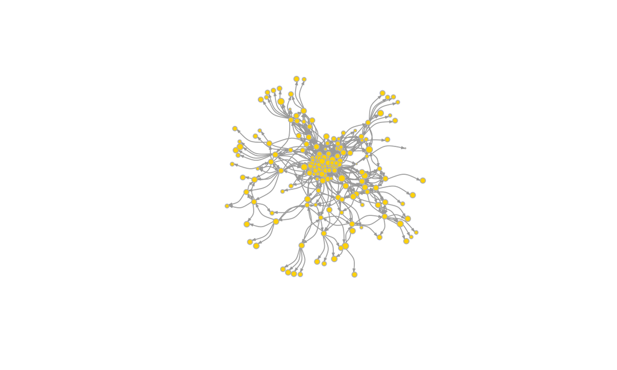

```r
library(igraph)
net=graph_from_data_frame(edge.list)
netsim=igraph::simplify(net, remove.multiple = T, remove.loops = F)
V(netsim)$id=V(netsim)$name

user.df=user.df %>%
  unique()%>%
    arrange(match(user_id, V(netsim)$id))
user.name=user.df%>%
  pull(name)
V(netsim)$name=user.name
V(netsim)$degree=user.df$friends_count
set.seed(123)
plot(netsim,vertex.name=V(netsim)$user.name,vertex.color="gold", vertex.size=log(V(netsim)$degree)*.8+0.01,
     vertex.frame.color="gray", vertex.label.color="black",
     vertex.label.cex=0.5, vertex.label.dist=2, edge.curved=0.5,edge.arrow.size=.2,vertex.label.cex=.5,vertex.label=NA)
```

## Other APIs

- `Rfacebook` (facebook) https://cran.r-project.org/web/packages/Rfacebook/Rfacebook.pdf
- `RedditExtractoR` (reddit) https://cran.r-project.org/web/packages/RedditExtractoR/RedditExtractoR.pdf
- `imdbapi` (IMDB) https://cran.r-project.org/web/packages/imdbapi/imdbapi.pdf
- `omdbapi`(The Open Movie Database) https://github.com/hrbrmstr/omdbapi

## API request directly from R

The movie database API https://www.themoviedb.org/

- Signup and request for an API key https://developers.themoviedb.org/3/getting-started/introduction
- Write functions to make query:
  - Create a query
  - From JSON file to dataframe
- Build your own network based on these functions

## preparation

```r
#install.packages("rjson")
library(rjson)
#install.packages("jsonlite")
library(jsonlite)
```

## search people id

Search people based on the name: https://developers.themoviedb.org/3/search/search-people

```r
### get actor/director id based on name
get_search_people = function(people,api="your-api-key"){

  search = URLencode(people, reserved = TRUE)

  people_url = paste0("https://api.themoviedb.org/3/search/person?api_key=",api,"&language=en-US&query=",
                      search,"&include_adult=false")
  people_json = jsonlite::fromJSON(paste(readLines(people_url), collapse=""))

  total_page = people_json$total_pages
  if (total_page > 1){
    people_id_df = data.frame()
    n = min(5, total_page)
    for (j in 1:n){
      url = paste0("https://api.themoviedb.org/3/search/person?api_key=",api,"&language=en-US&query=",
                   search,"&page=",j,"&include_adult=false")
      json = jsonlite::fromJSON(paste(readLines(people_url), collapse=""))
      temp = json$results %>% as.data.frame() %>% select(id, name)
      people_id_df = rbind(people_id_df, temp)
    }
  } else {
    people_id_df = people_json$results %>% as.data.frame() %>% select(id, name)
  }

  return(people_id_df) # this dataframe only contains name and people id

}
actress="Julianne Moore" # She comes from NC
get_search_people(actress)
```

## search movies based on people id

Search the movies of one person based on id:https://developers.themoviedb.org/3/people/get-person-movie-credits

```r
# get movie details of one person with the person id
get_people_movie = function(id,api="your-api-key"){

  url = paste0("https://api.themoviedb.org/3/person/",id,"/movie_credits?api_key=",api,"&language=en-US")
  people_movie_json = jsonlite::fromJSON(paste(readLines(url), collapse=""))
  people_movie_df = people_movie_json$cast %>% as.data.frame() %>% select(character, poster_path, id, vote_average, original_language,
                                                                          title, popularity, overview, release_date)
  base_url = "http://image.tmdb.org/t/p/w500"
  people_movie_df = people_movie_df %>% mutate(poster_path = paste0(base_url, poster_path))

  return(people_movie_df)

}
id=1231 # got from the previous function `get_search_people`
get_people_movie(id)
```